```r
# Part A: Dataset Loading and Understanding
# 1. Load Required Libraries and Dataset

library(ggplot2)
library(dplyr)
data("economics")
```

```r
# 2. Structure and Summary Statistics
str(economics)
```

```
## spc_tbl_ [574 × 6] (S3: spec_tbl_df/tbl_df/tbl/data.frame)
##  $ date    : Date[1:574], format: "1967-07-01" "1967-08-01" ...
##  $ pce     : num [1:574] 507 510 516 512 517 ...
##  $ pop     : num [1:574] 198712 198911 199113 199311 199498 ...
##  $ psavert : num [1:574] 12.6 12.6 11.9 12.9 12.8 11.8 11.7 12.3 11.7 12.3 ...
##  $ uempmed : num [1:574] 4.5 4.7 4.6 4.9 4.7 4.8 5.1 4.5 4.1 4.6 ...
##  $ unemploy: num [1:574] 2944 2945 2958 3143 3066 ...
```

```r
summary(economics)
```

```
##       date                 pce               pop            psavert
##  Min.   :1967-07-01   Min.   :  506.7   Min.   :198712   Min.   : 2.200
##  1st Qu.:1979-06-08   1st Qu.: 1578.3   1st Qu.:224896   1st Qu.: 6.400
##  Median :1991-05-16   Median : 3936.8   Median :253060   Median : 8.400
##  Mean   :1991-05-17   Mean   : 4820.1   Mean   :257160   Mean   : 8.567
##  3rd Qu.:2003-04-23   3rd Qu.: 7626.3   3rd Qu.:290291   3rd Qu.:11.100
##  Max.   :2015-04-01   Max.   :12193.8   Max.   :320402   Max.   :17.300
##     uempmed          unemploy
##  Min.   : 4.000   Min.   : 2685
##  1st Qu.: 6.000   1st Qu.: 6284
##  Median : 7.500   Median : 7494
##  Mean   : 8.609   Mean   : 7771
##  3rd Qu.: 9.100   3rd Qu.: 8686
##  Max.   :25.200   Max.   :15352
```

Explanation of Important Variables:

date The date variable represents the time at which each economic observation was recorded. It is crucial for time-series analysis as it allows us to study trends, patterns, and changes in economic indicators over a period of time, such as growth, recession, or recovery phases.

unemploy The unemploy variable indicates the total number of unemployed individuals in the United States for a given date. It is a key indicator of economic health, as higher unemployment generally reflects economic slowdown, while lower unemployment suggests economic stability and growth.

pce (Personal Consumption Expenditure) The pce variable measures the total amount spent by consumers on goods and services. It is an important indicator of consumer behavior and economic activity, as increased consumption usually signals higher confidence in the economy.

pop (Population) The pop variable represents the total population size at each time point. It is significant for normalization and comparative analysis, helping analysts understand economic measures like unemployment or consumption relative to population growth.

psavert (Personal Savings Rate) The psavert variable shows the percentage of personal income saved by individuals. It reflects financial stability and consumer confidence, where higher savings may indicate cautious spending behavior, while lower savings may suggest higher consumption.

```r
# 4. Data Types and Date Conversion
class(economics$date)
```

```
## [1] "Date"
```

```r
economics$date <- as.Date(economics$date)
```

```r
# 5. Missing Value Check
colSums(is.na(economics))
```

```
##     date      pce      pop  psavert  uempmed unemploy
##        0        0        0        0        0        0
```

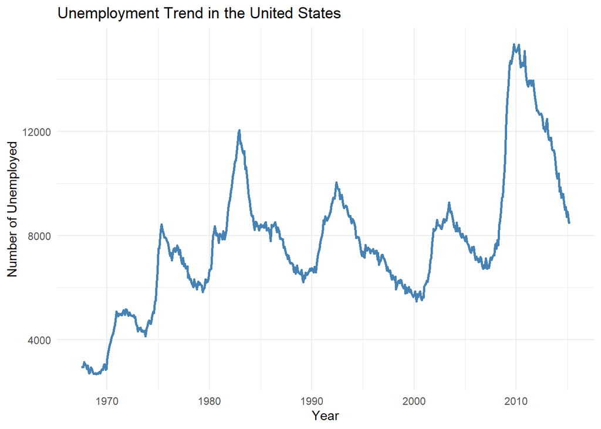

```r
# Part B: Basic Time-Series Visualizations
# 1. Line Plot: Unemployment Over Time
ggplot(economics, aes(x = date, y = unemploy)) +
  geom_line(color = "steelblue", size = 1) +
  labs(
    title = "Unemployment Trend in the United States",
    x = "Year",
    y = "Number of Unemployed"
  ) +
  theme_minimal()
```

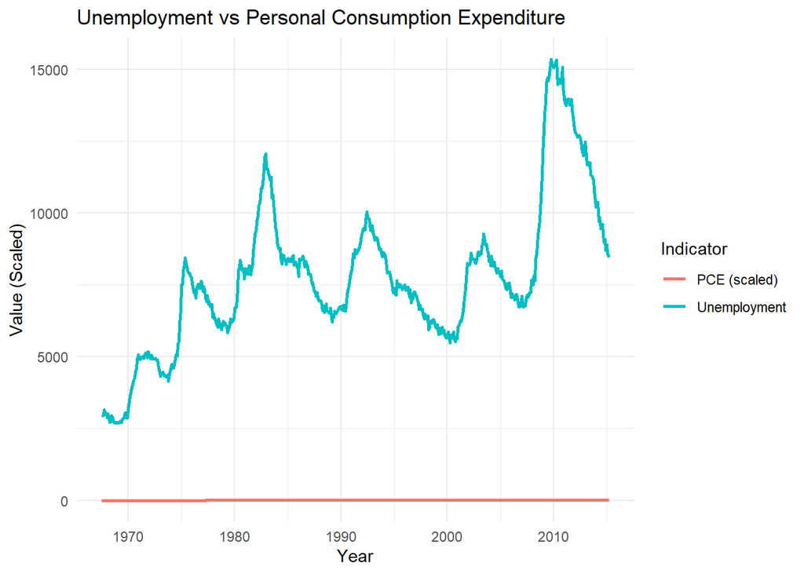

```r
# 2. Comparison: Unemployment vs Personal Consumption
ggplot(economics, aes(x = date)) +
  geom_line(aes(y = unemploy, color = "Unemployment"), size = 1) +
  geom_line(aes(y = pce / 1000, color = "PCE (scaled)"), size = 1) +
  labs(
    title = "Unemployment vs Personal Consumption Expenditure",
    x = "Year",
    y = "Value (Scaled)",
    color = "Indicator"
  ) +
  theme_minimal()
```

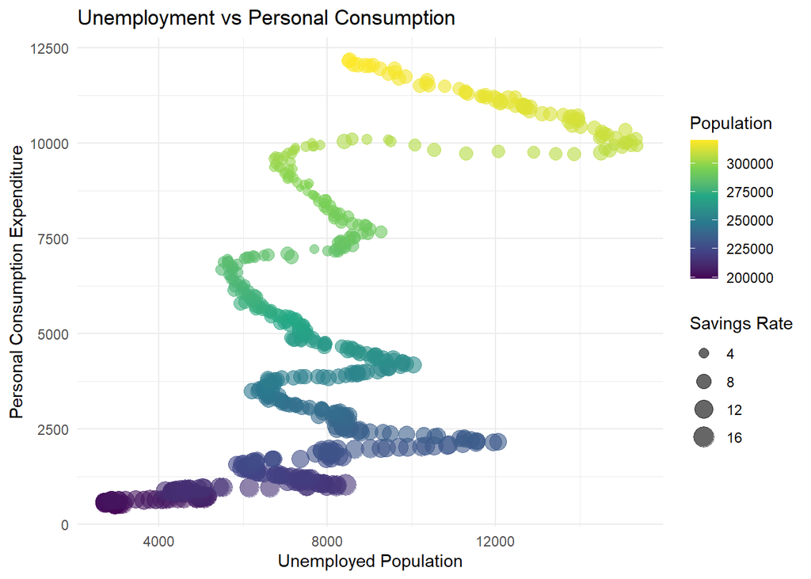

```r
# Part C: Aesthetics and Geometries
# 1. Scatter Plot: Unemployment vs PCE
ggplot(economics, aes(x = unemploy, y = pce)) +
  geom_point(
    aes(color = pop, size = psavert),
    alpha = 0.6
  ) +
  scale_color_viridis_c() +
  labs(
    title = "Unemployment vs Personal Consumption",
    x = "Unemployed Population",
    y = "Personal Consumption Expenditure",
    color = "Population",
    size = "Savings Rate"
  ) +
  theme_minimal()
```

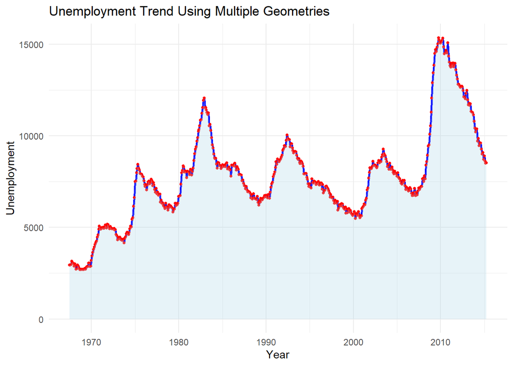

```r
# 2. Multiple Geometries for Unemployment Trend
ggplot(economics, aes(x = date, y = unemploy)) +
  geom_line(color = "blue", size = 1) +
  geom_point(color = "red", size = 1) +
  geom_area(fill = "lightblue", alpha = 0.3) +
  labs(
    title = "Unemployment Trend Using Multiple Geometries",
    x = "Year",
    y = "Unemployment"
  ) +
  theme_minimal()
```

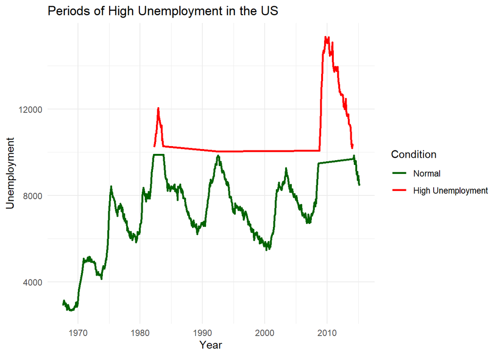

```r
# 3. Highlight High Unemployment Periods
ggplot(economics, aes(x = date, y = unemploy)) +
  geom_line(aes(color = unemploy > 10000), size = 1) +
  scale_color_manual(
    values = c("FALSE" = "darkgreen", "TRUE" = "red"),
    labels = c("Normal", "High Unemployment")
  ) +
  labs(
    title = "Periods of High Unemployment in the US",
    x = "Year",
    y = "Unemployment",
    color = "Condition"
  ) +
  theme_minimal()
```

```r
# Part D: Faceting and Grouped Analysis
# 1. Extraction of Year from Date Variable
economics <- economics %>%
  mutate(year = format(date, "%Y"))
```

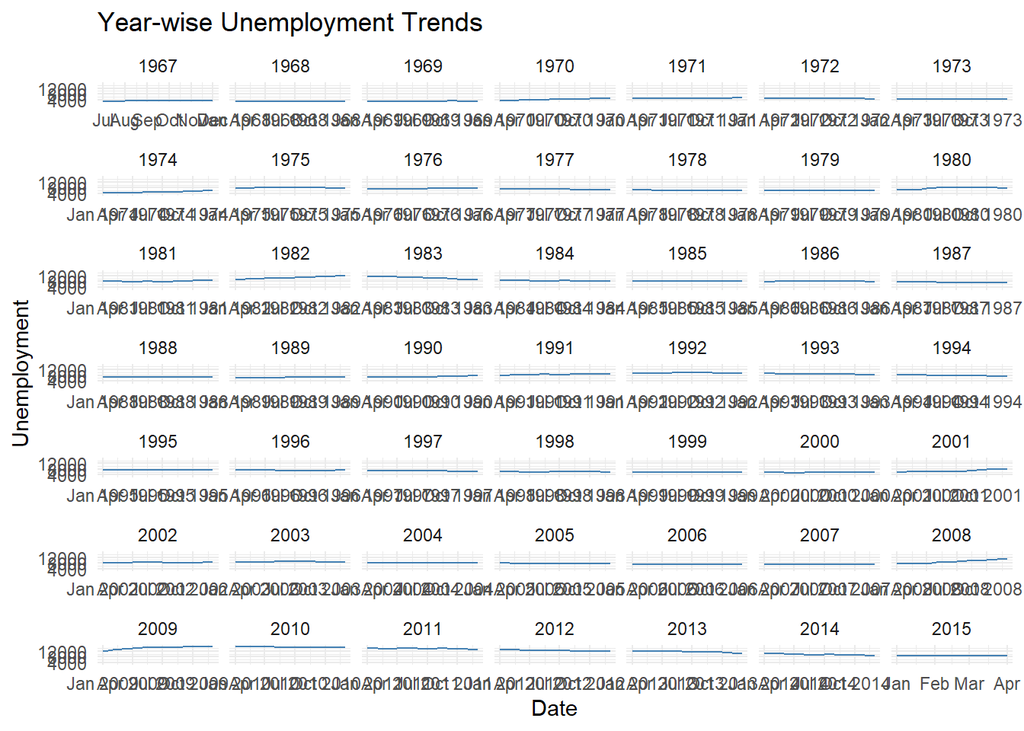

```r
# 2. Faceted Plots for Unemployment Trends
ggplot(economics, aes(x = date, y = unemploy)) +
  geom_line(color = "steelblue") +
  facet_wrap(~ year, scales = "free_x") +
  labs(
    title = "Year-wise Unemployment Trends",
    x = "Date",
    y = "Unemployment"
  ) +
  theme_minimal()
```

[figure not shown]

```r
# 3. Faceted Comparison of Savings Rate and Consumption
ggplot(economics, aes(x = date, y = psavert)) +
  geom_line(color = "darkgreen") +
  facet_wrap(~ year) +
  labs(title = "Savings Rate Across Years") +
  theme_minimal()
```

[figure not shown]

```r
ggplot(economics, aes(x = date, y = pce)) +
  geom_line(color = "purple") +
  facet_wrap(~ year) +
  labs(title = "Personal Consumption Expenditure Across Years") +
  theme_minimal()
```

**Interpretation of Faceted Patterns**

The faceted plots reveal that unemployment, savings rate, and consumption fluctuate differently across years. Economic downturns show higher unemployment and savings rates, while stable periods reflect increased consumption and reduced savings, indicating higher consumer confidence.

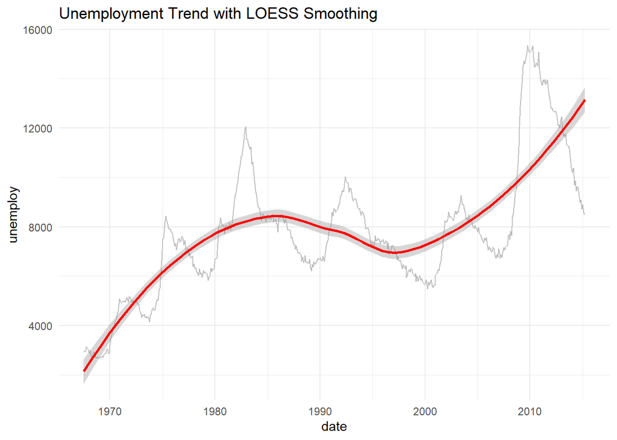

```r
# Part E: Statistical Layers and Trend Analysis
# 1. Adding Smooth Trend Lines
ggplot(economics, aes(x = date, y = unemploy)) +
  geom_line(color = "gray") +
  geom_smooth(method = "loess", color = "red") +
  labs(title = "Unemployment Trend with LOESS Smoothing") +
  theme_minimal()
```

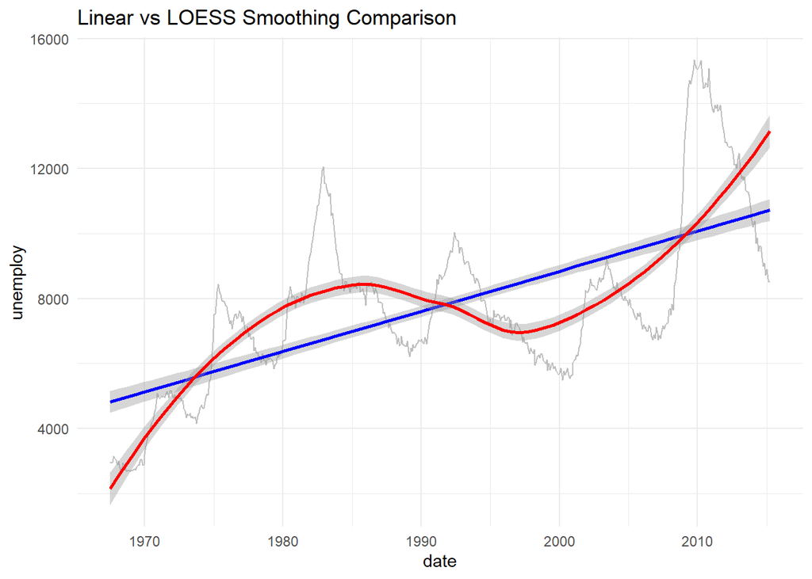

```r
# 2. Comparison of Linear and LOESS Smoothing
ggplot(economics, aes(x = date, y = unemploy)) +
  geom_line(color = "gray") +
  geom_smooth(method = "lm", color = "blue") +
  geom_smooth(method = "loess", color = "red") +
  labs(title = "Linear vs LOESS Smoothing Comparison") +
  theme_minimal()
```

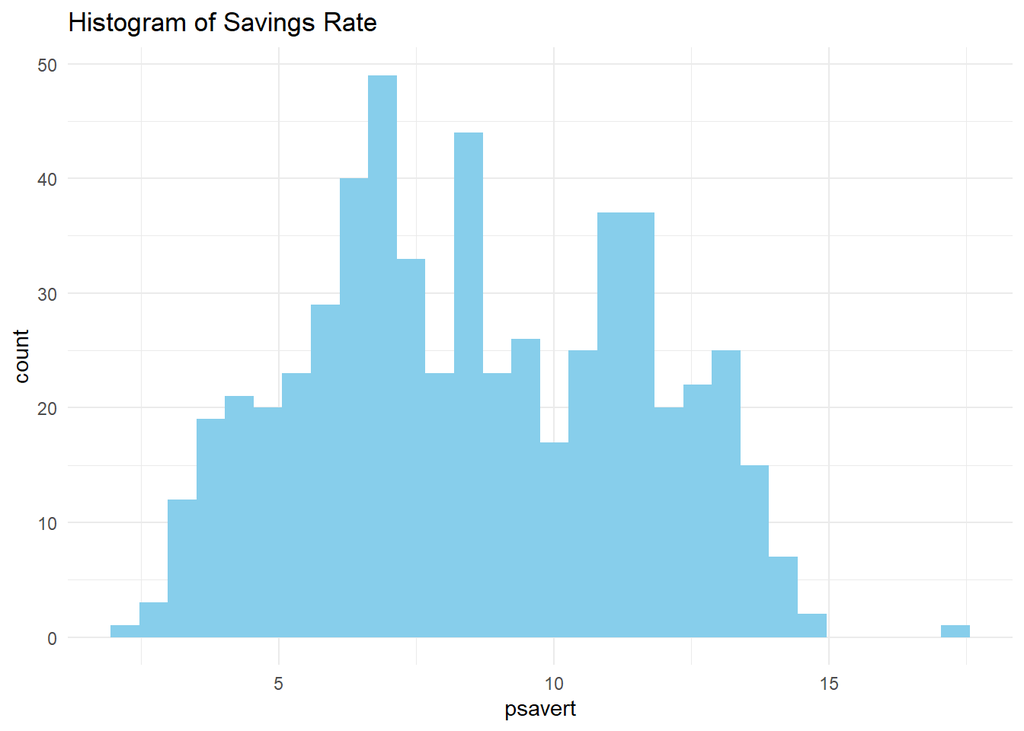

```r
# 3. Distribution of Savings Rate
ggplot(economics, aes(x = psavert)) +
  geom_histogram(fill = "skyblue", bins = 30) +
  labs(title = "Histogram of Savings Rate") +
  theme_minimal()
```

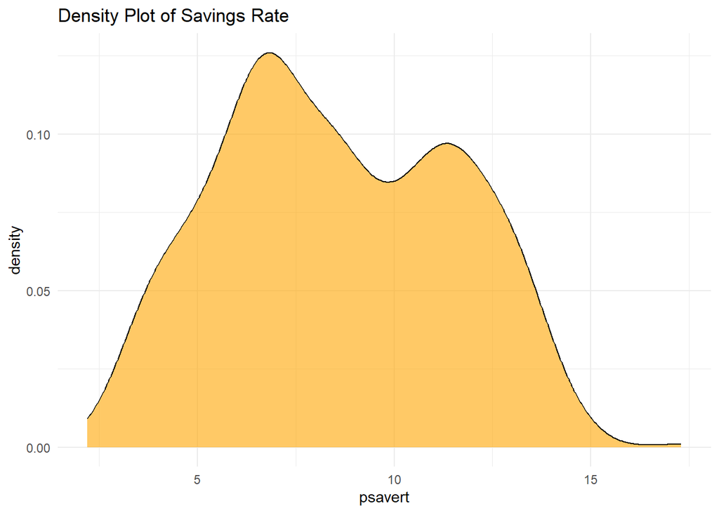

```r
ggplot(economics, aes(x = psavert)) +
  geom_density(fill = "orange", alpha = 0.6) +
  labs(title = "Density Plot of Savings Rate") +
  theme_minimal()
```

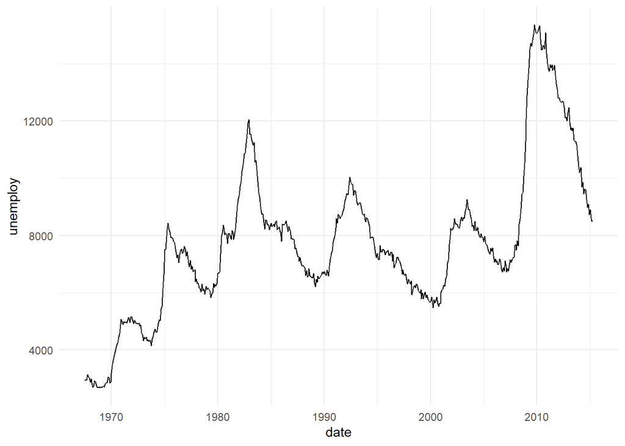

```r
# Part F: Themes and Plot Customization
# Application of Different Themes
ggplot(economics, aes(x = date, y = unemploy)) +
  geom_line() +
  theme_minimal()
```

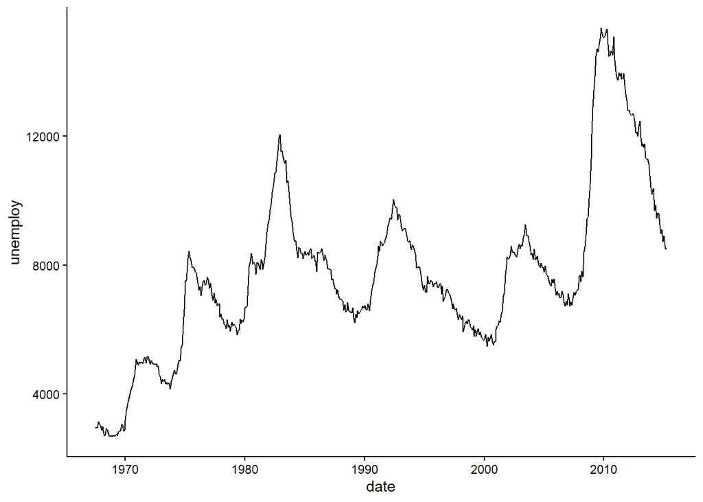

```r
ggplot(economics, aes(x = date, y = unemploy)) +
  geom_line() +
  theme_classic()
```

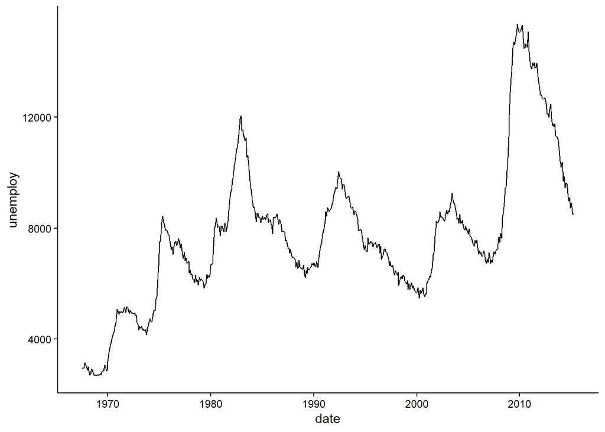

```r
ggplot(economics, aes(x = date, y = unemploy)) +
  geom_line() +
  theme_classic()
```

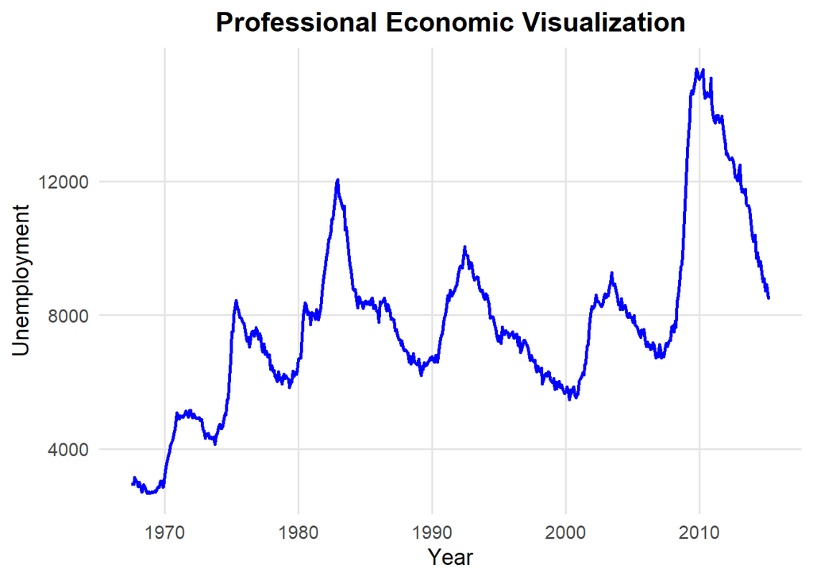

```r
# 2. Customization of Plot Components
ggplot(economics, aes(x = date, y = unemploy)) +
  geom_line(color = "blue", size = 1) +
  labs(
    title = "Professional Economic Visualization",
    x = "Year",
    y = "Unemployment"
  ) +
  theme_minimal(base_size = 14) +
  theme(
    plot.title = element_text(face = "bold", hjust = 0.5),
    legend.position = "bottom",
    panel.grid.major = element_line(color = "gray90"),
    panel.grid.minor = element_blank()
  )
```

3. **Professional Visualization Outcome**  
   Through proper theme selection and customization, the final visualization achieves a clean, readable, and professional appearance suitable for economic reports and presentations.

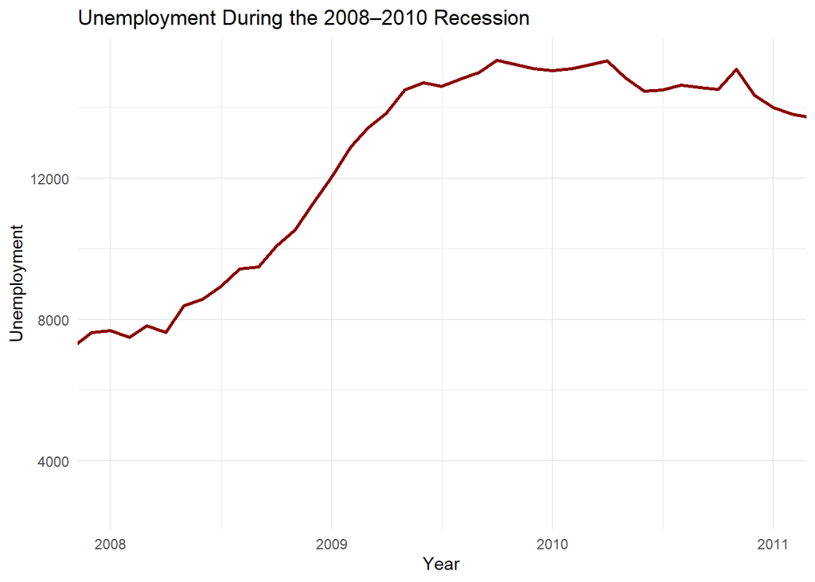

   ```r
   # Part G: Coordinate Systems and Advanced Views
   # Zooming into a Specific Economic Recession using coord_cartesian()
   ggplot(economics, aes(x = date, y = unemploy)) +
     geom_line(color = "darkred", size = 1) +
     coord_cartesian(
       xlim = as.Date(c("2008-01-01", "2010-12-31"))
     ) +
     labs(
       title = "Unemployment During the 2008–2010 Recession",
       x = "Year",
       y = "Unemployment"
     ) +
     theme_minimal()
   ```

   ```r
   # Applying coord_flip() and Its Impact on Readability
   library(lubridate)
   ```

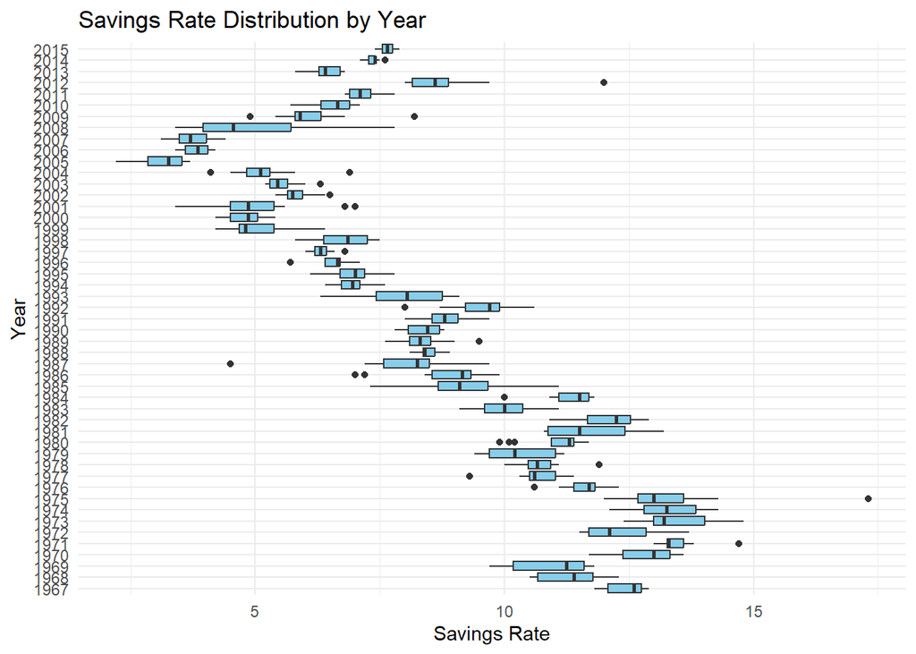

   ```r
   ggplot(economics, aes(
     x = factor(year(date)),
     y = psavert
   )) +
     geom_boxplot(fill = "skyblue") +
     coord_flip() +
     labs(
       title = "Savings Rate Distribution by Year",
       x = "Year",
       y = "Savings Rate"
     ) +
     theme_minimal()
   ```

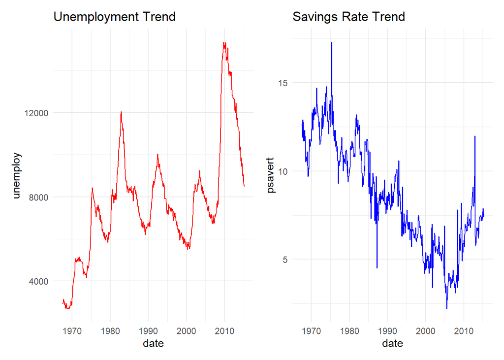

   ```r
   # Dual Visualization Layout for Comparative Analysis
   library(patchwork)

   p1 <- ggplot(economics, aes(x = date, y = unemploy)) +
     geom_line(color = "red") +
     labs(title = "Unemployment Trend") +
     theme_minimal()

   p2 <- ggplot(economics, aes(x = date, y = psavert)) +
     geom_line(color = "blue") +
     labs(title = "Savings Rate Trend") +
     theme_minimal()

   p1 + p2
   ```

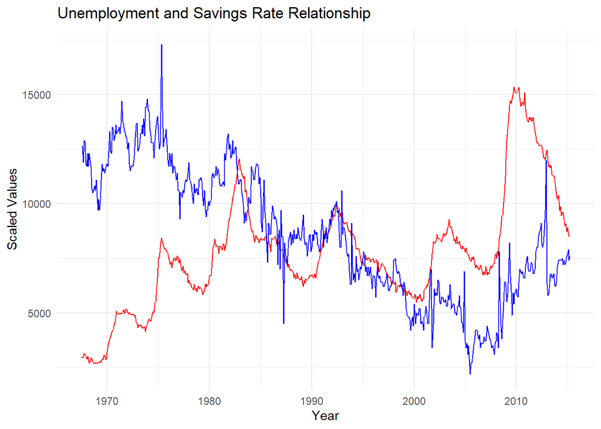

   ```r
   # Part I: Exploratory and Open-Ended Tasks
   # 1. Custom Visualization for Economic Insight
   ggplot(economics, aes(x = date)) +
     geom_line(aes(y = unemploy), color = "red") +
     geom_line(aes(y = psavert * 1000), color = "blue") +
     labs(
       title = "Unemployment and Savings Rate Relationship",
       x = "Year",
       y = "Scaled Values"
     ) +
     theme_minimal()
   ```

**Role of Visualization in Policy Making and Forecasting**

Well-designed economic visualizations help policymakers quickly identify trends, assess the severity of recessions, and evaluate the effectiveness of economic policies. In forecasting, visual analysis supports early detection of warning signs such as rising unemployment or declining consumption.